# Model definition for traits in GAO

## IntTrCSA

Covlist: `Agesc, Agesc2, Sexf`.

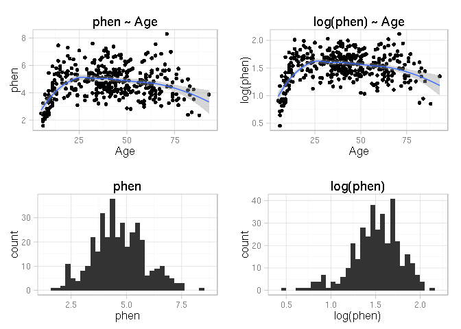

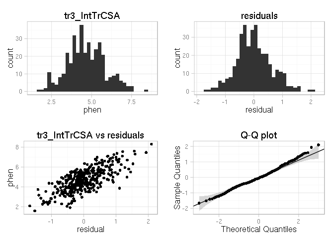

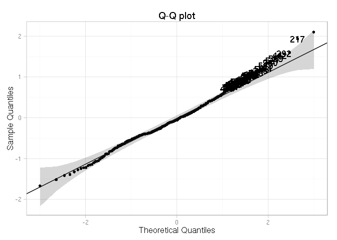

## IntTrCSMI

Covlist: `Agesc, Agesc2, Sexf, NegDrug`.

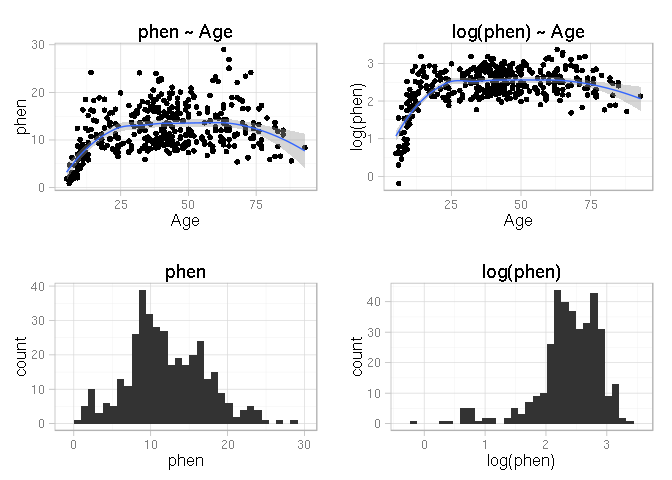

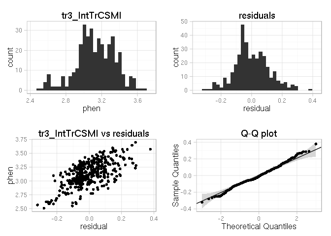

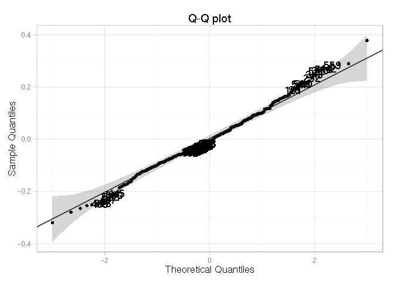

## IntTrSMod

Covlist: `Agesc, Agesc2, Sexf`.

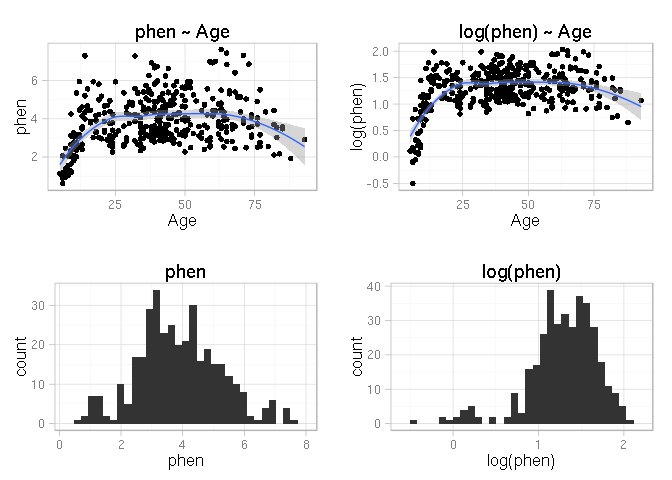

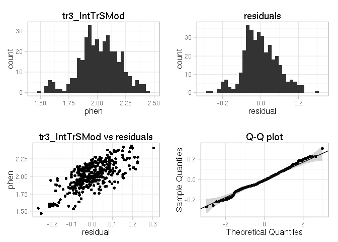

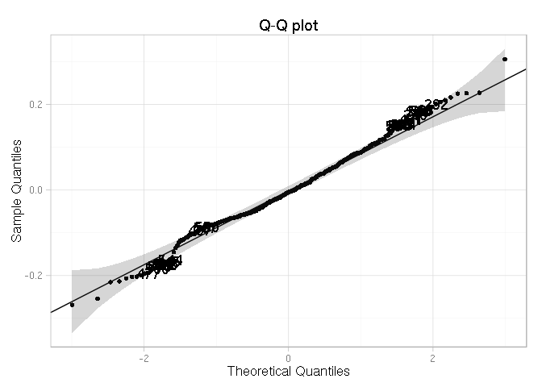

## NeckBMD

Covlist: `Agesc, Agesc2, Sexf`.

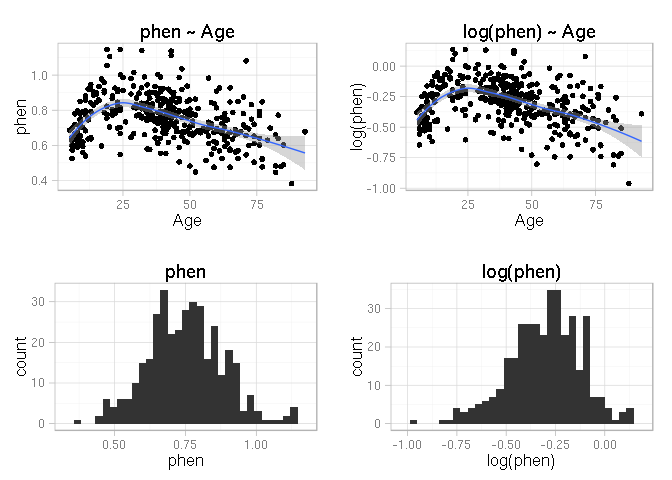

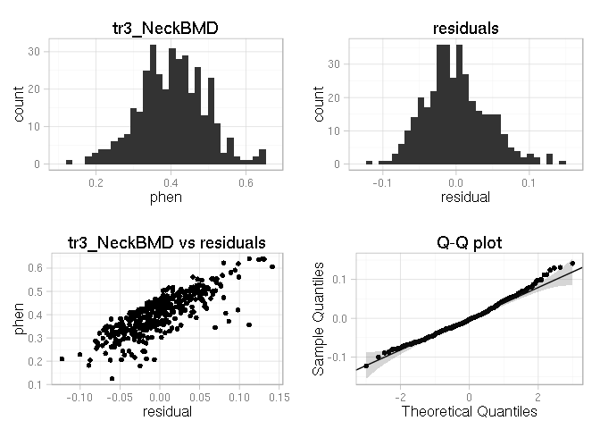

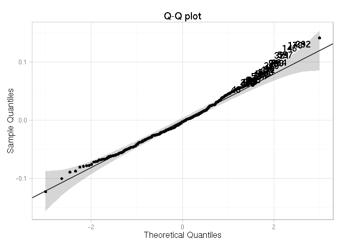

## NNeckACT

Covlist: `Agesc, Agesc2, Sexf`.

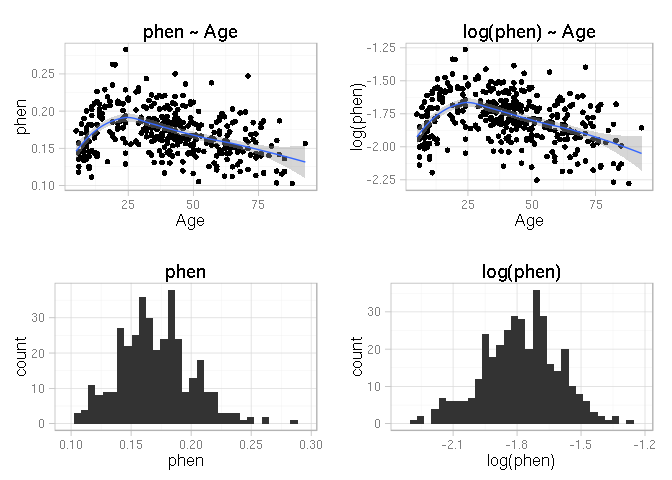

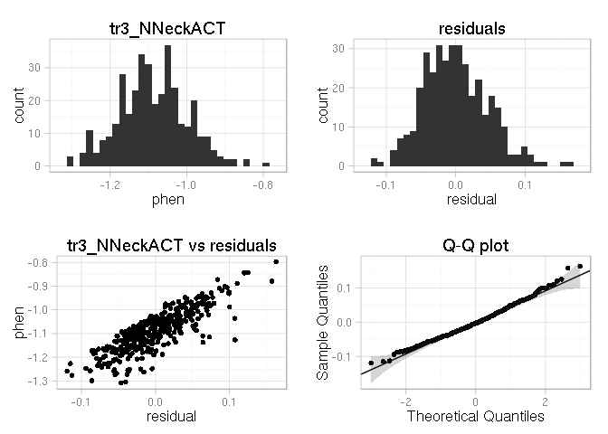

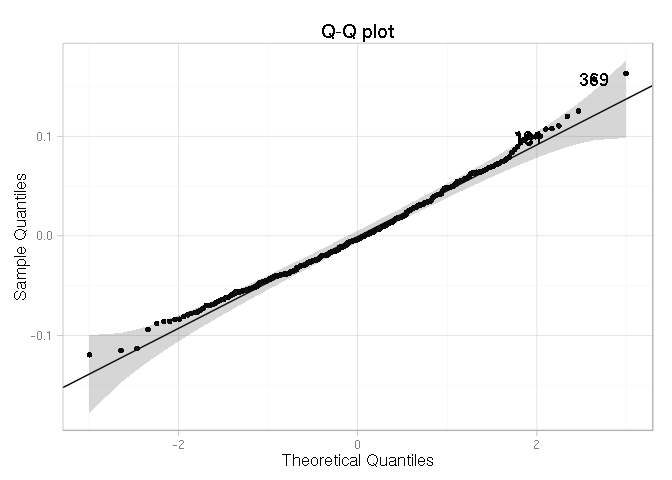

## NNeckBR

Covlist: `Agesc, Sexf`.

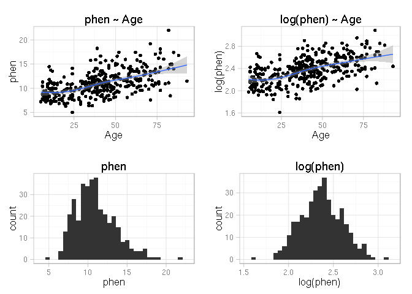

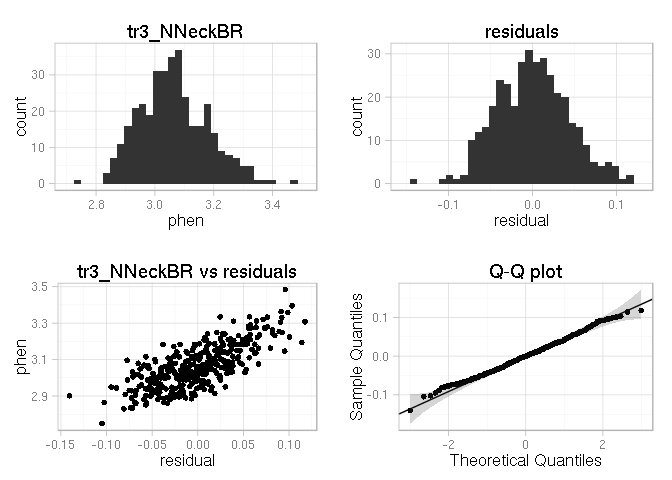

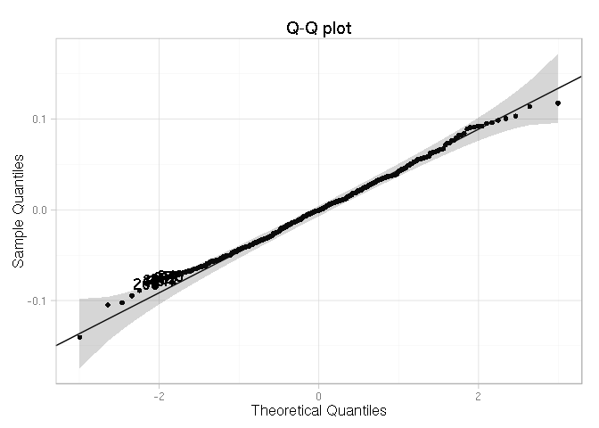

## NNeckCSA

Covlist: `Agesc, Agesc2, Sexf`.

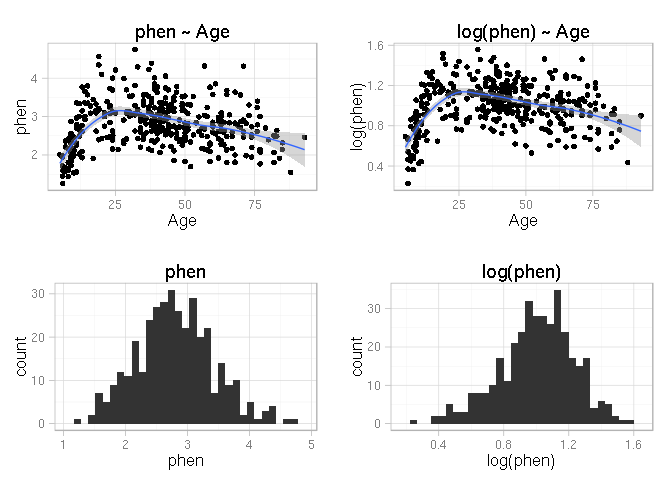

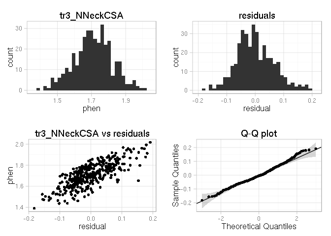

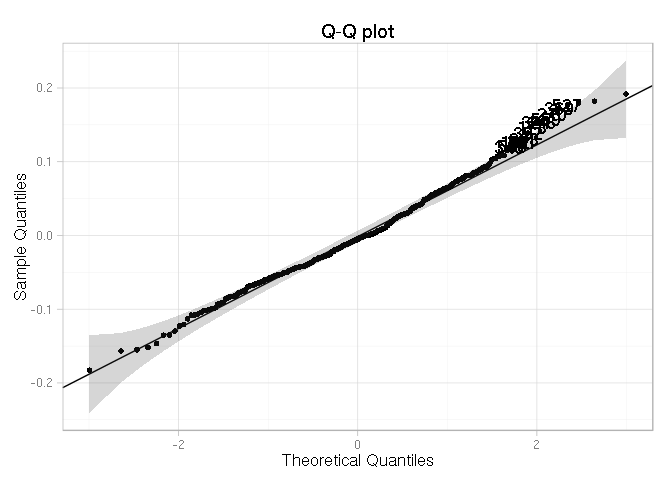

## NNeckCSMI

Covlist: `Agesc, Agesc2, Sexf`.

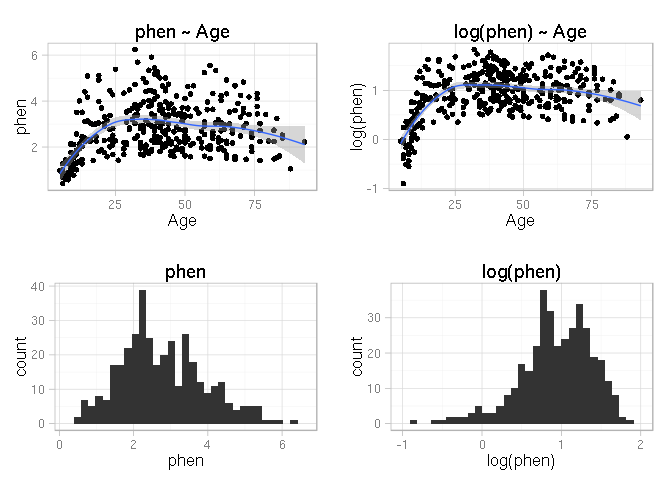

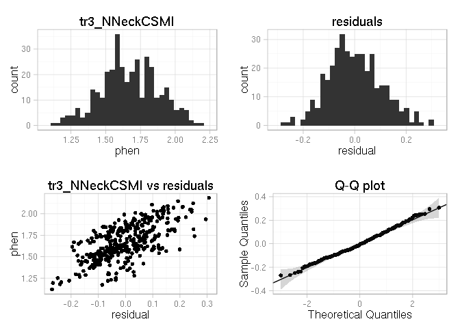

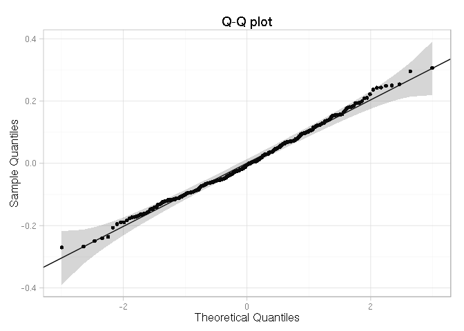

## NNeckSMod

Covlist: `Agesc, Agesc2, Sexf`.

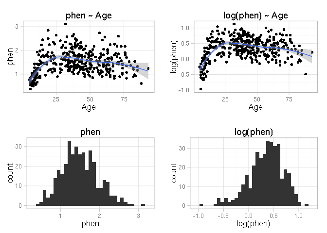

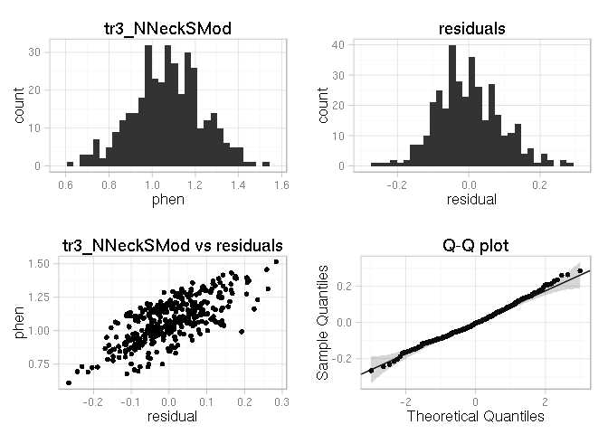

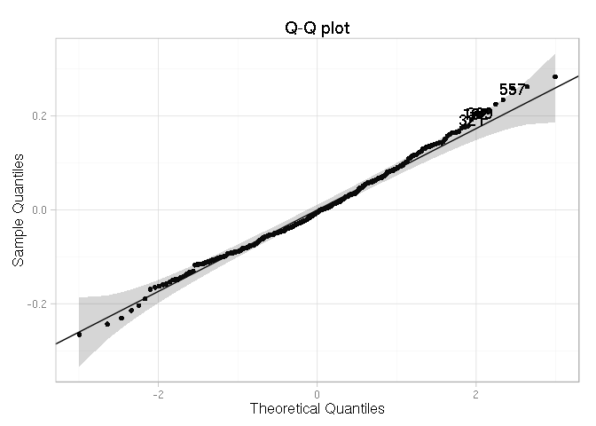

## ShaftNeck

Covlist: `Agesc, Sexf`.

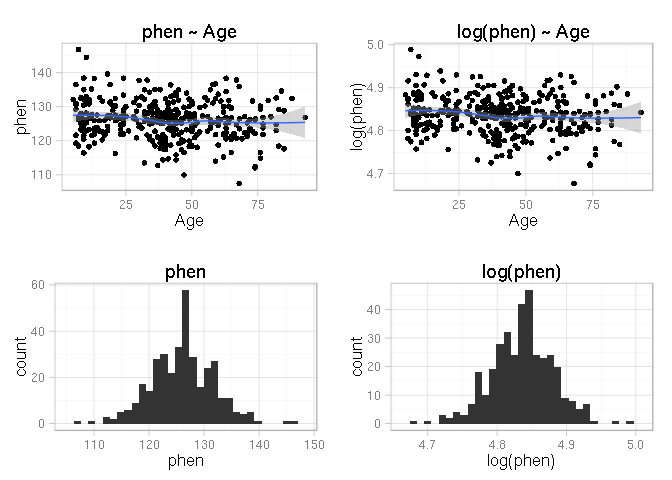

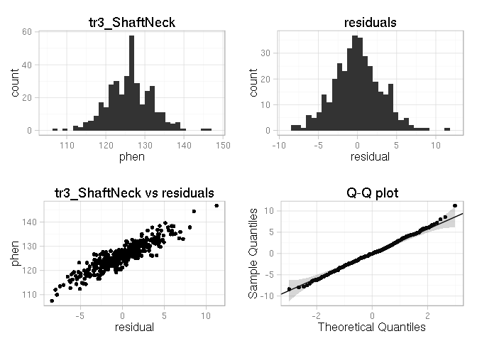

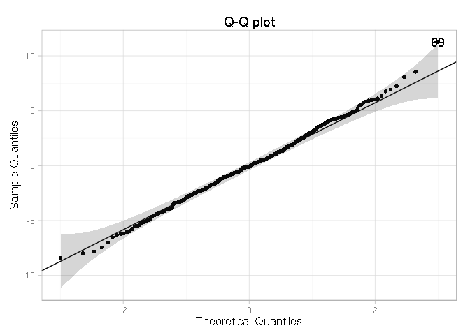

## TotBMD

Covlist: `Agesc, Agesc2, PosDrug`.

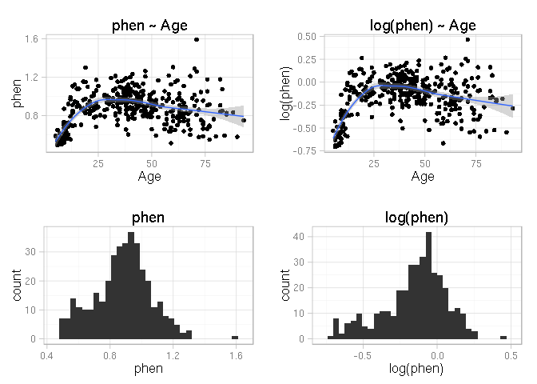

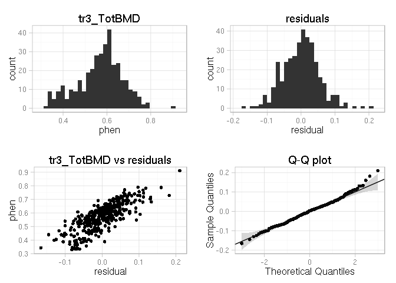

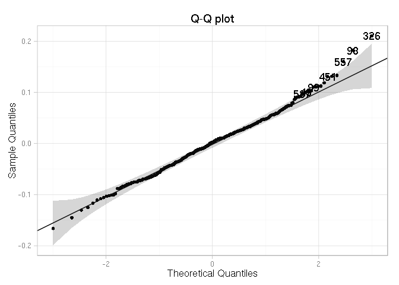

## TrochBMD

Covlist: `Agesc, Agesc2, Sexf`.

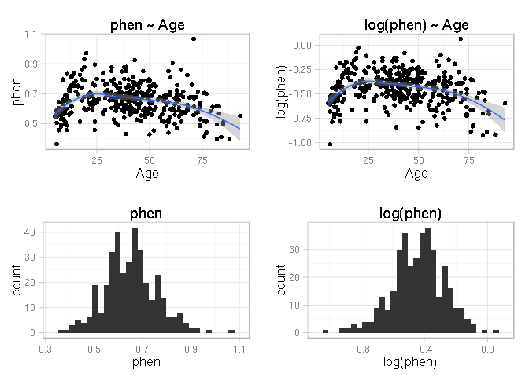

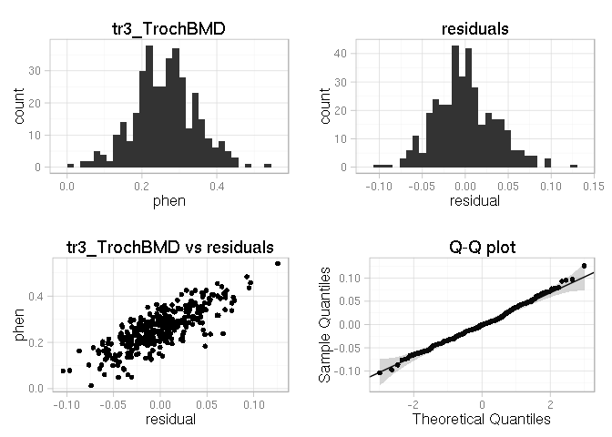

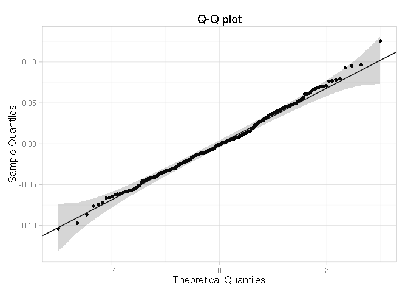

## WBTotArea

Covlist: `Agesc, Agesc2, Sexf`.

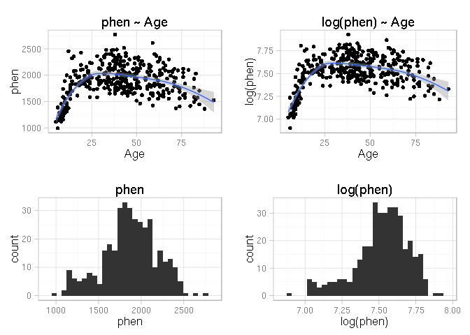

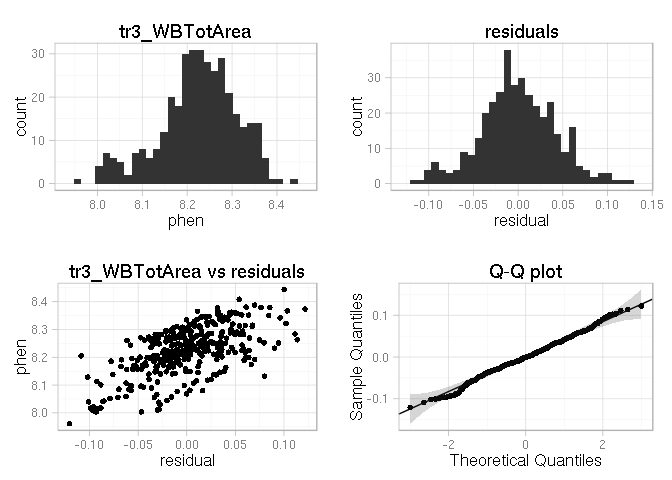

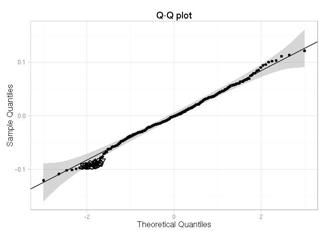

## WBTotBMC

Covlist: `Agesc, Agesc2, Sexf`.

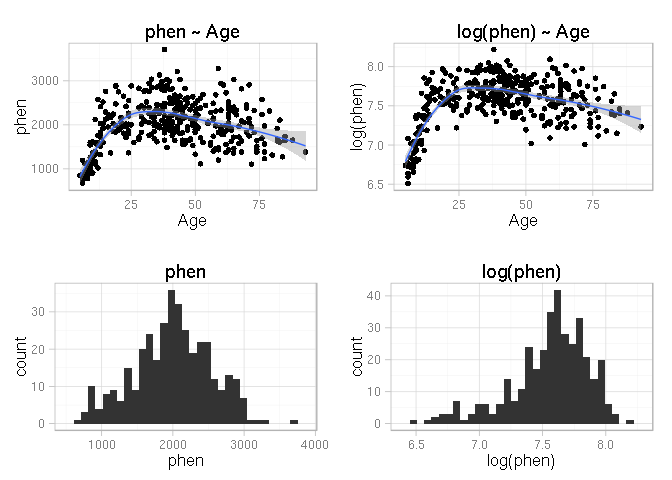

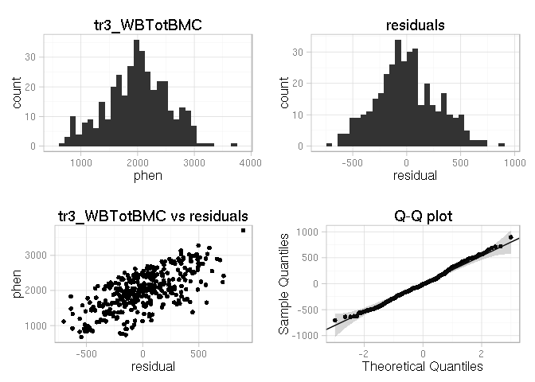

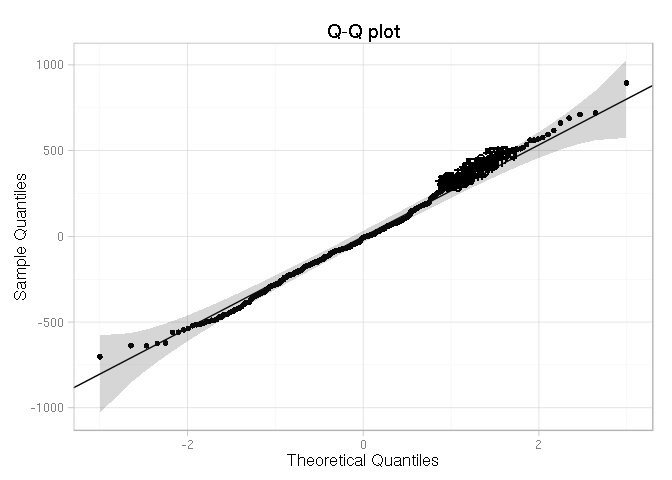

## WBTotBMD

Covlist: `Agesc, Agesc2, Sexf`.

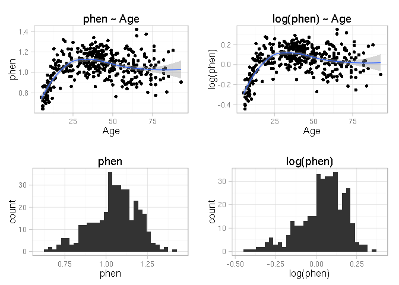

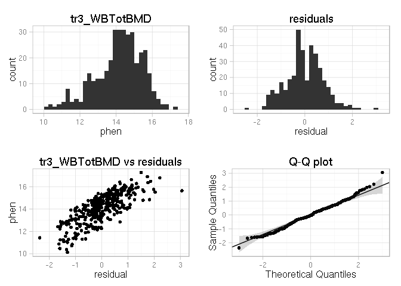

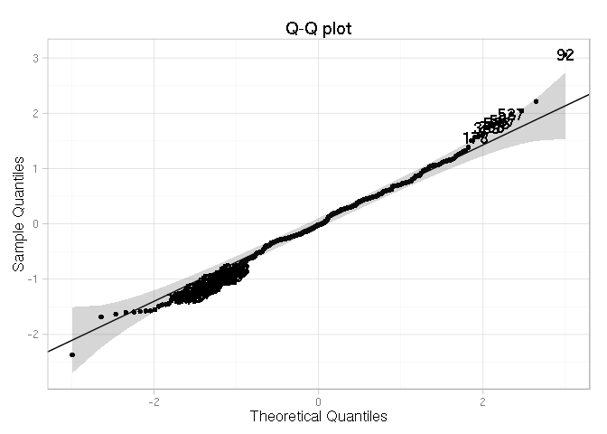

## WBTotFat

Covlist: `Agesc, Agesc2, Sexf, Alcohol`.

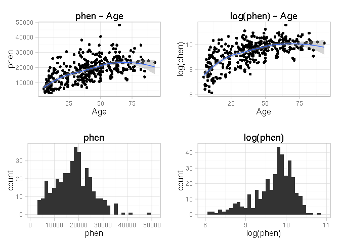

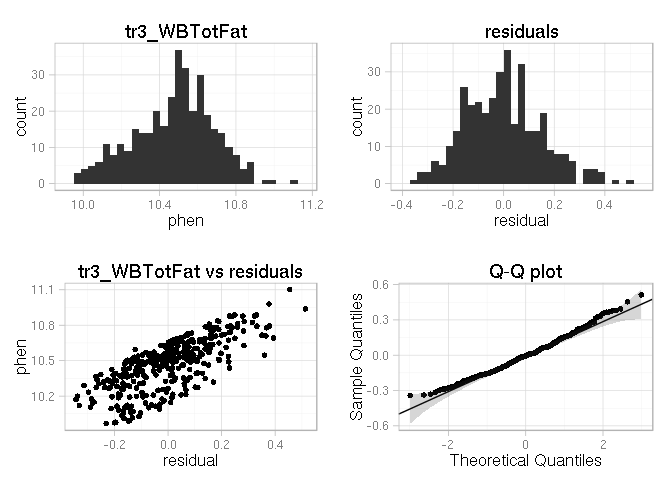

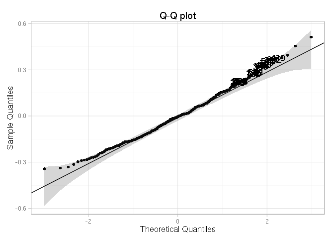

## WBTotLean

Covlist: `Agesc, Agesc2, Sexf, Alcohol`.

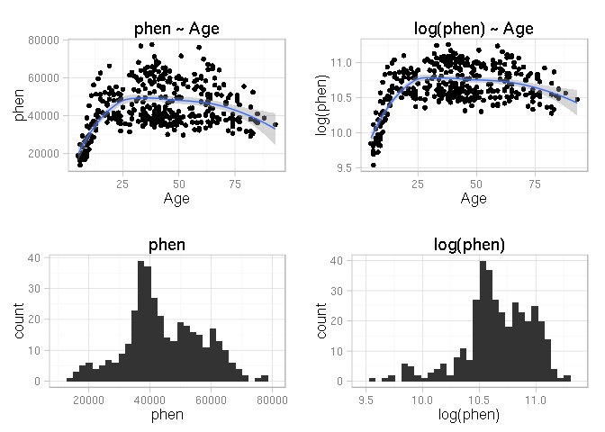

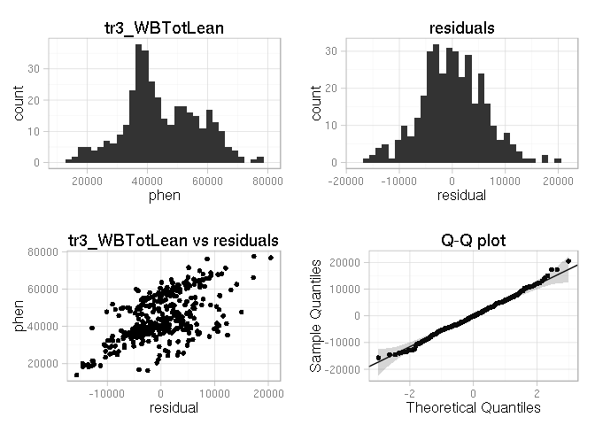

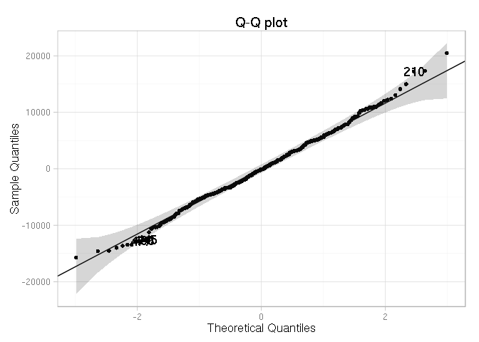

## HydVitD

Covlist: `PosDrug`.

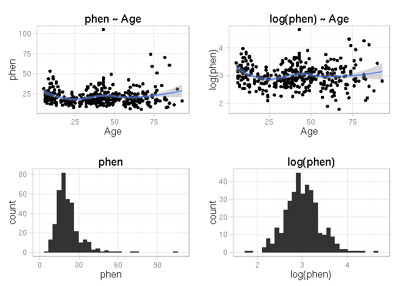

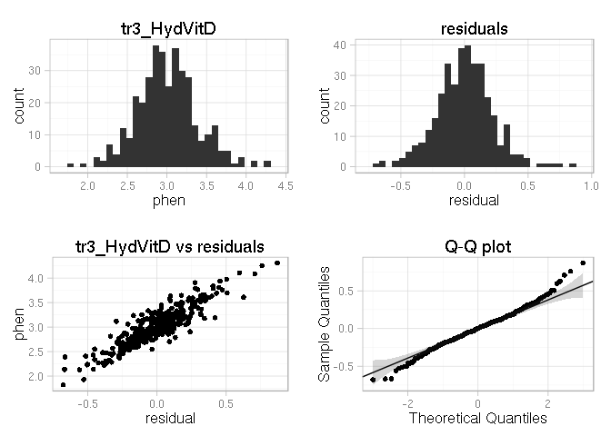

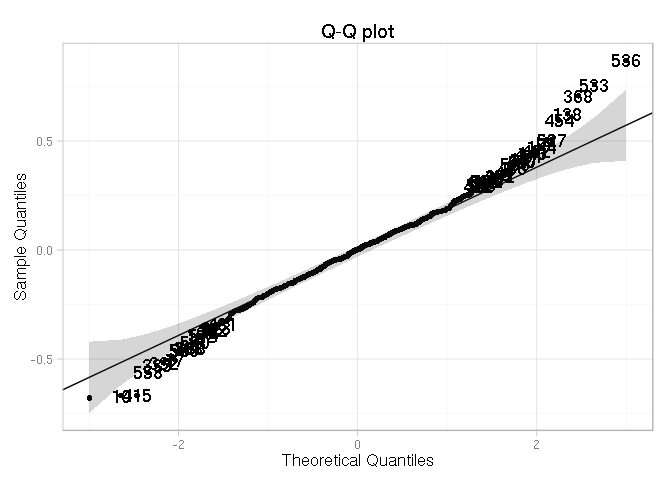

## Sclerostin

Covlist: `Agesc, Agesc2, Sexf`.

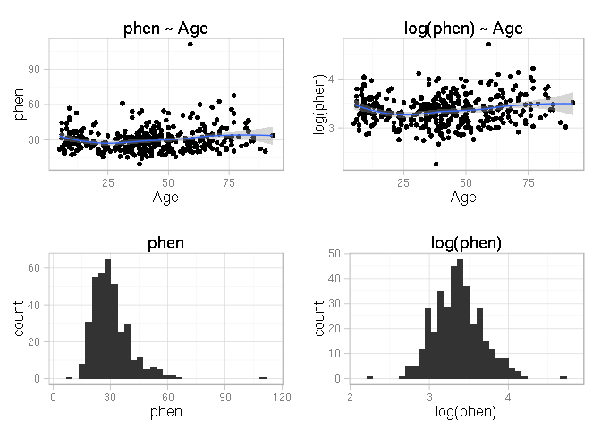

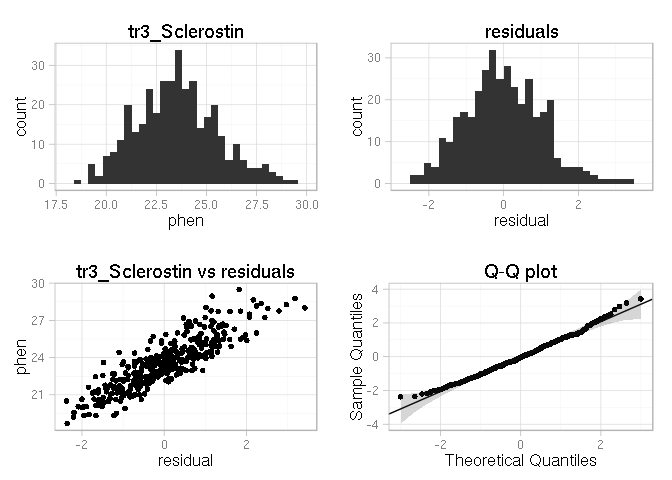

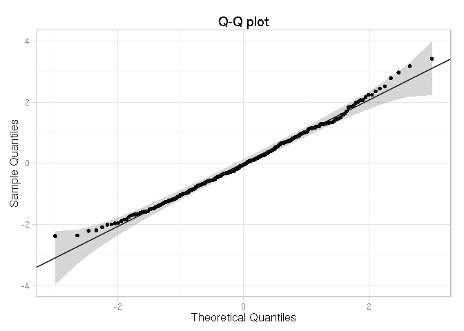

## SerCrossLaps

Covlist: `Agesc, Agesc2, Sexf`.

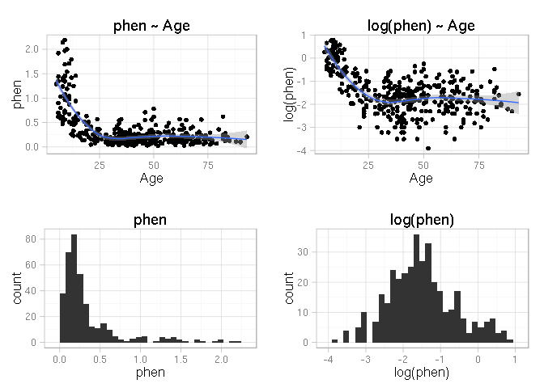

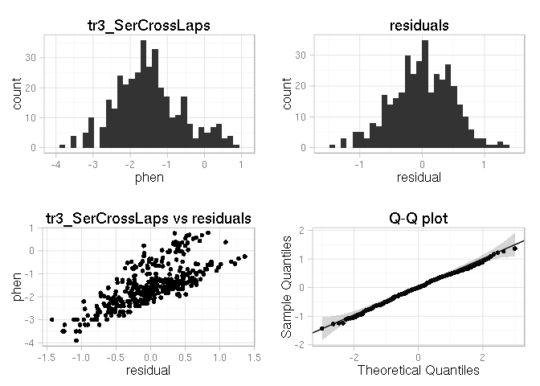

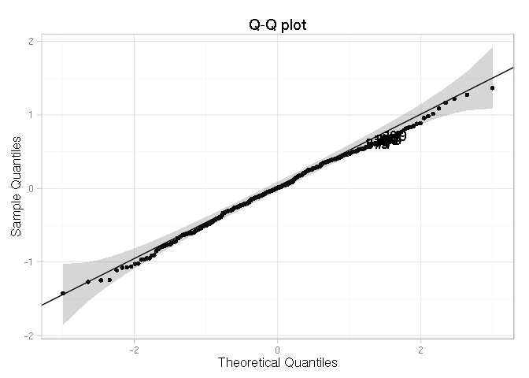